# Predict the species of flower and compare the regression models

Radhika Sood

## Summary

**Goal**: To compare the performace of the various models on predicting the species of the flower.

**Results**: SVM and Random Forests gave 100% accuracy

```r
library(kableExtra)
library(rattle)
library(corrplot)
library(dplyr)
library(ggplot2)
library(GGally)
library(ggthemes)
library(plotly)
library(tidyr)
library(caTools)
library(DT)
library(gridExtra)
library(ROCR)
library(leaps)
library(PRROC)
library(boot)
library(naniar)
library(psych)
library(grid)
library(ggplot2)
library(lattice)
library(caret) # Use cross-validation
library(class)
library(rpart) # Decision Tree
library(caretEnsemble)
library(e1071)
library(kernlab)
```

## Data Cleaning

Structure of the dataset

```
## 'data.frame':    150 obs. of  6 variables:
##  $ id         : int  1 2 3 4 5 6 7 8 9 10 ...
##  $ SepalLength: num  5.1 4.9 4.7 4.6 5 5.4 4.6 5 4.4 4.9 ...
##  $ SepalWidth : num  3.5 3 3.2 3.1 3.6 3.9 3.4 3.4 2.9 3.1 ...
##  $ PetalLength: num  1.4 1.4 1.3 1.5 1.4 1.7 1.4 1.5 1.4 1.5 ...
##  $ PetalWidth : num  0.2 0.2 0.2 0.2 0.2 0.4 0.3 0.2 0.2 0.1 ...
##  $ Species    : chr  "Iris-setosa" "Iris-setosa" "Iris-setosa" "Iris-setosa" ...
```

The structure shows that the dataset has 5 numeric and 1 categorical variable.

Check for null, duplicate values

```
##      id          SepalLength     SepalWidth      PetalLength
##  Mode :logical   Mode :logical   Mode :logical   Mode :logical
##  FALSE:150       FALSE:150       FALSE:150       FALSE:150
##  PetalWidth       Species
##  Mode :logical   Mode :logical
##  FALSE:150       FALSE:150
```

```
## [1] FALSE
```

```
## [1] 150
```

Look at the missing values

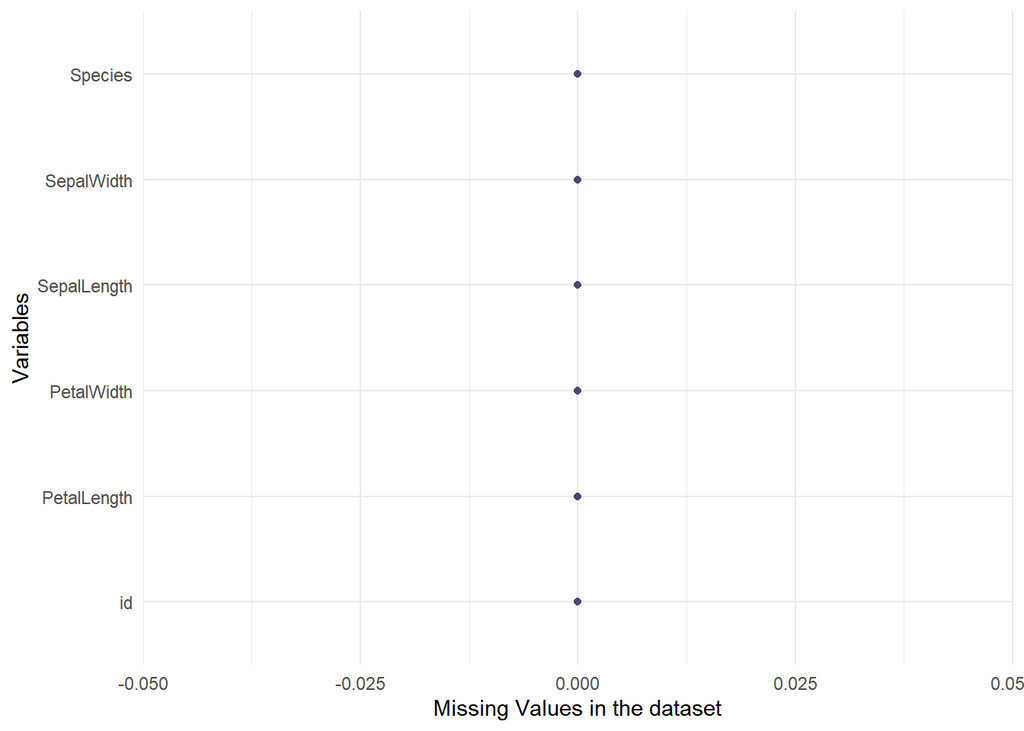

The graph shows that there is no missing value

Get final glimse of the data

```
## Observations: 150
## Variables: 6
## $ id          <int> 1, 2, 3, 4, 5, 6, 7, 8, 9, 10, 11, 12, 13, 14, 15, 16, ...
## $ SepalLength <dbl> 5.1, 4.9, 4.7, 4.6, 5.0, 5.4, 4.6, 5.0, 4.4, 4.9, 5.4, ...
## $ SepalWidth  <dbl> 3.5, 3.0, 3.2, 3.1, 3.6, 3.9, 3.4, 3.4, 2.9, 3.1, 3.7, ...
## $ PetalLength <dbl> 1.4, 1.4, 1.3, 1.5, 1.4, 1.7, 1.4, 1.5, 1.4, 1.5, 1.5, ...
## $ PetalWidth  <dbl> 0.2, 0.2, 0.2, 0.2, 0.2, 0.4, 0.3, 0.2, 0.2, 0.1, 0.2, ...
## $ Species     <chr> "Iris-setosa", "Iris-setosa", "Iris-setosa", "Iris-seto...
```

## Data Visualization

### Distribution

Check for distribution of variables in the dataset using histogram

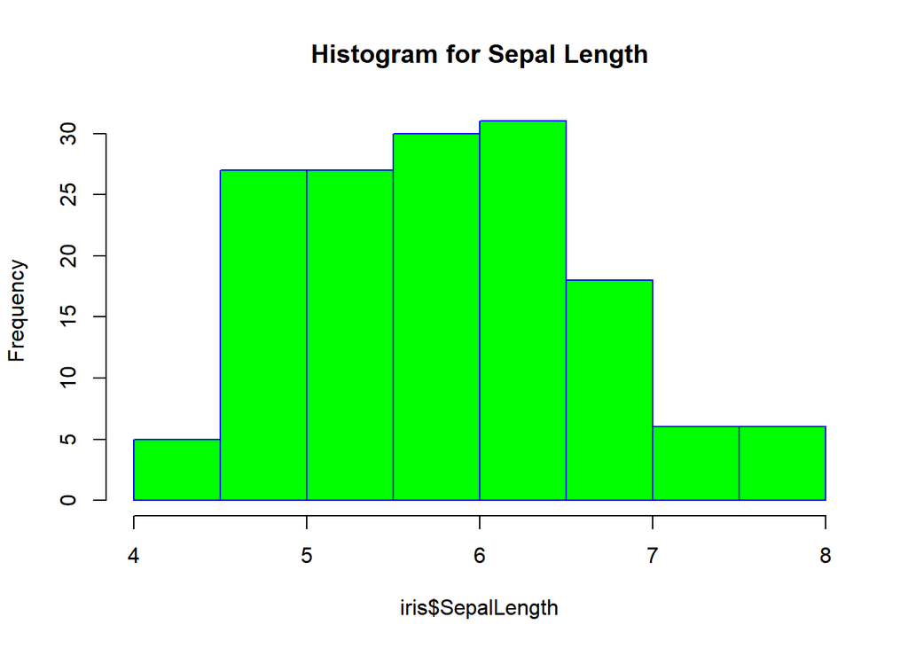

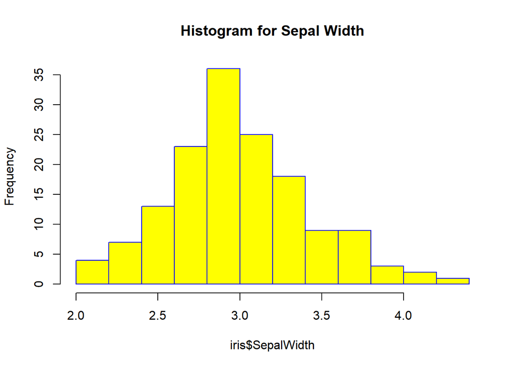

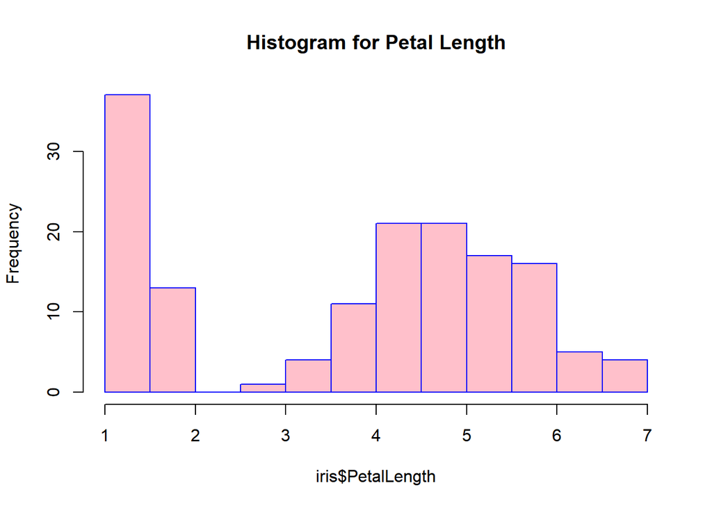

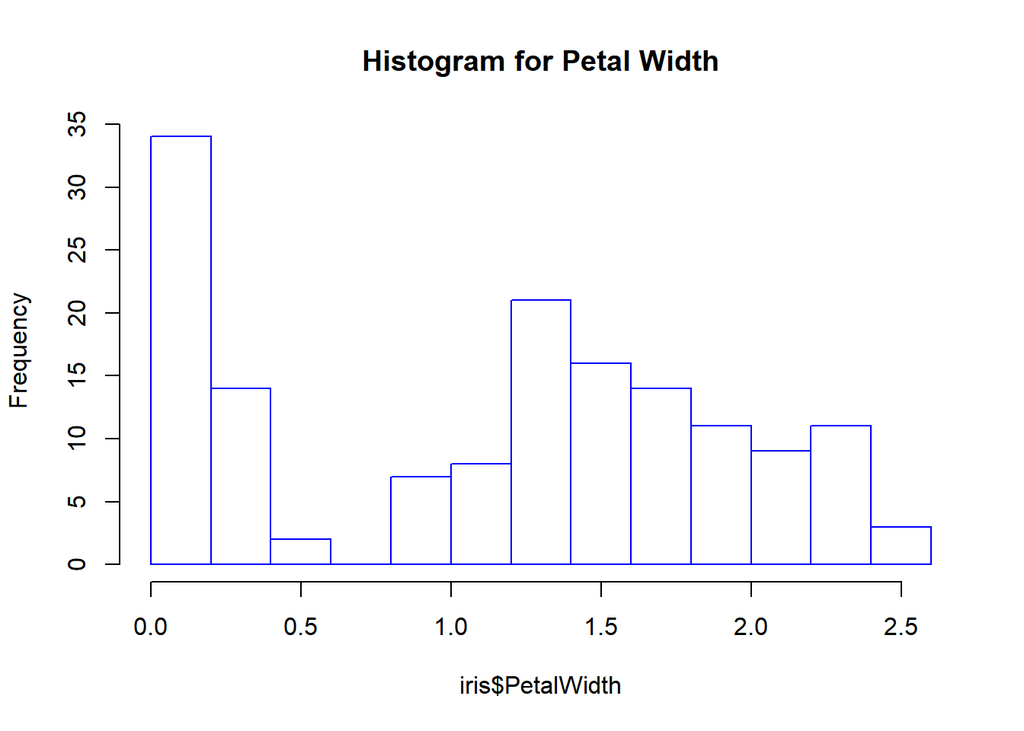

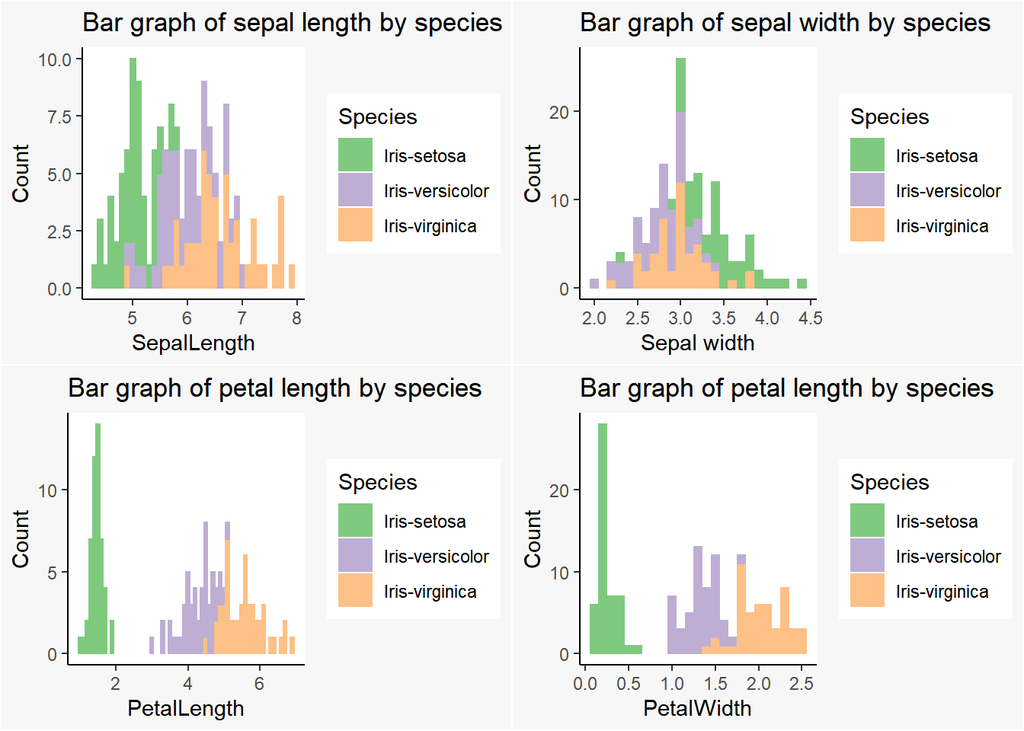

### Correlation

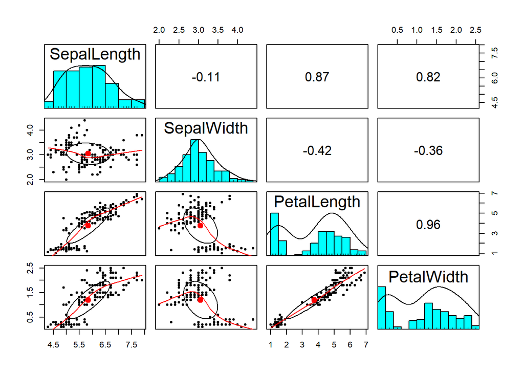

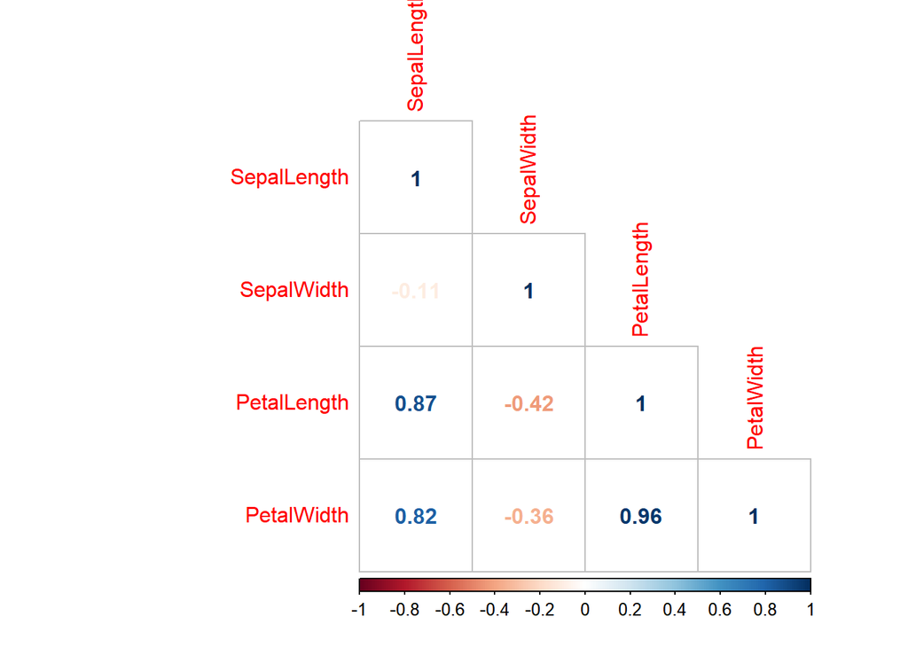

### Outliers

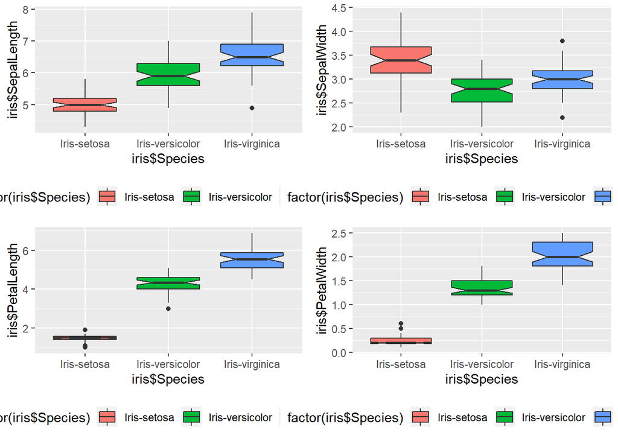

```
## Observations: 150
## Variables: 6
## $ id          <int> 1, 2, 3, 4, 5, 6, 7, 8, 9, 10, 11, 12, 13, 14, 15, 16, ...
## $ SepalLength <dbl> 5.1, 4.9, 4.7, 4.6, 5.0, 5.4, 4.6, 5.0, 4.4, 4.9, 5.4, ...
## $ SepalWidth  <dbl> 3.5, 3.0, 3.2, 3.1, 3.6, 3.9, 3.4, 3.4, 2.9, 3.1, 3.7, ...
## $ PetalLength <dbl> 1.4, 1.4, 1.3, 1.5, 1.4, 1.7, 1.4, 1.5, 1.4, 1.5, 1.5, ...
## $ PetalWidth  <dbl> 0.2, 0.2, 0.2, 0.2, 0.2, 0.4, 0.3, 0.2, 0.2, 0.1, 0.2, ...
## $ Species     <chr> "Iris-setosa", "Iris-setosa", "Iris-setosa", "Iris-seto...
```

## K-NN

#### Clasification Accuracy

The Accuracy from knn is:

```
## [1] 97.22222
```

```
## [1] 97.22222
```

```
## [1] 97.22222
```

```
## [1] 100
```

```
## [1] 100
```

```
## [1] 100
```

## Decision Tree

The predicted accuracy the decision tree model by running it on resamples of the train data.

```
## Cross-Validated (10 fold) Confusion Matrix
##
## (entries are percentual average cell counts across resamples)
##
##           Reference
## Prediction    0    1    2
##          0 33.3  0.0  0.0
##          1  0.0 30.7  4.4
##          2  0.0  2.6 28.9
##
##  Accuracy (average) : 0.9298
```

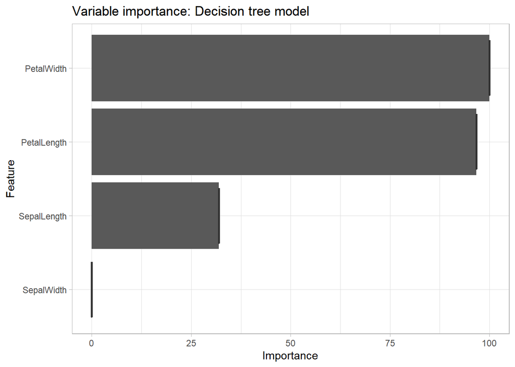

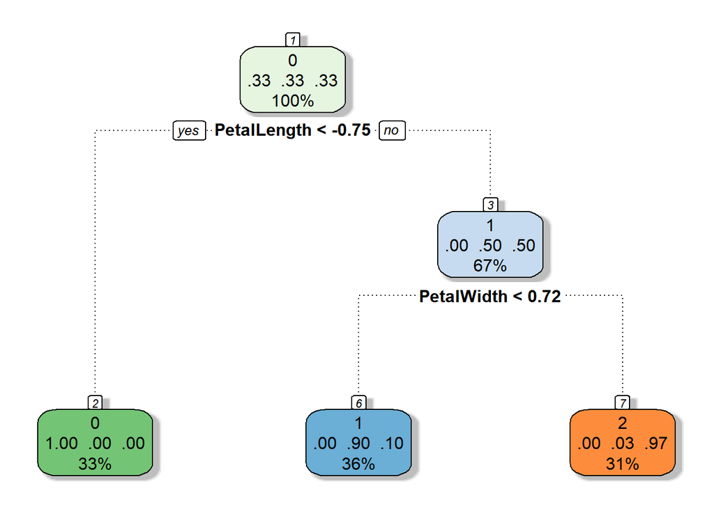

The Accuracy from decision tree is:

```
## [1] 97.22222
```

## Random Forest

```
## Cross-Validated (10 fold) Confusion Matrix
##
## (entries are percentual average cell counts across resamples)
##
##           Reference
## Prediction    0    1    2
##          0 33.3  0.0  0.0
##          1  0.0 30.7  3.5
##          2  0.0  2.6 29.8
##
##  Accuracy (average) : 0.9386
```

The accuracy from random forest is:

```
## [1] 100
```

## NB

The predicted accuracy the Naive Bayes model by running it on resamples of the train data.

```
## Cross-Validated (10 fold) Confusion Matrix
##
## (entries are percentual average cell counts across resamples)
##
##           Reference
## Prediction    0    1    2
##          0 33.3  0.0  0.0
##          1  0.0 31.6  2.6
##          2  0.0  1.8 30.7
##
##  Accuracy (average) : 0.9561
```

```
##    nb_predict
##      0  1  2
##   0 12  0  0
##   1  0 11  1
##   2  0  0 12
```

The accuracy from Naive Beyes is:

```
## [1] 97.22222
```

## SVM

The predicted accuracy the SVM model by running it on resamples of the train data.

```
## Cross-Validated (10 fold) Confusion Matrix
##
## (entries are percentual average cell counts across resamples)
##
##           Reference
## Prediction    0    1    2
##          0 33.3  0.0  0.0
##          1  0.0 29.8  2.6
##          2  0.0  3.5 30.7
##
##  Accuracy (average) : 0.9386
```

The accuracy from SVM is:

```
## [1] 100
```